# Final project TN3156: Simulating Superradiance

##### Authors: Andrei Moşescu, Mario Nicolae, Matthias Fransen, Axel Koning

##### Group number: 11

## Introduction

During the first half of the 20th century, most models used by scientists to describe spontaneous radiative processes occurring in gasses still treated each atom as a separate, independent two-level system (TLS) [1]. However, this model did not match accurately to real-world observations of emitted power. In 1953, R. Dicke improved the model by including the interaction of these TLSs with a common electromagnetic field (and thus indirectly with each other). Due to this interaction, the group of TLSs is able to radiate a coherent (in-phase) burst when decaying from excited state to ground state. Furthermore, the peak power will scale by the number of TLSs squared. This phenomenon is called superradiance and it occurs in systems consisting of a group of TLSs provided that:

- The wavelength of the electromagnetic field is much larger than the distance between the TLSs [2]
- The number of TLSs is sufficiently large (as will be shown visually later)

In this report we will discuss the physics behind superradiance and perform simulations that show the emergence of the phenomenon as well as the influence of certain disturbances.

## Description of the physical problem

Figure 1 shows a schematic representation of the set-up used for the simulations.

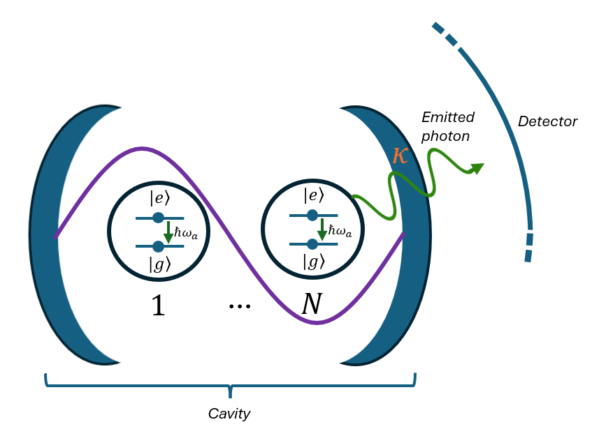

*Figure 1: Schematic visual of setup used. The purple line represents the cavity field. Symbols used are explained below*.

A number ($N$) of two-level systems (TLSs) are placed inside an optical cavity [3]. The TLSs will be initialized in the excited state $\lvert e \rangle$. Over time, these TLSs will decay to the ground state $\lvert g \rangle$ and simultaneously emit a photon of energy $\hbar \omega_a$. One of the mirrors of the cavity is 'leaky' and the corresponding cavity decay rate is quantified by $\kappa$. The photons that pass through the leaky mirror are detected by a photonic detector

The start conditions of the system are characterized by the vacuum electromagnetic (EM) field in the cavity and all TLSs in the excited state. Even when no photons are present yet, there is a vacuum EM-field due to zero-point fluctuations[4]. The photons emitted when the TLSs decay will strengthen this EM-field (making it non-vacuum), allowing for stronger interaction between the TLSs. The Hamiltonian that describes the interaction between the TLSs and the cavity field is the *Dicke Hamiltonian* ($\hat H_D$) and it is given by the following equation [5]:

$$ \hat H_D = \omega_c\, \hat{a}^\dagger \hat{a} + \omega_a\, \hat{J}_z + \frac{g_0}{\sqrt{N}} \left( \hat{a} + \hat{a}^\dagger \right) \left( \hat{J}_+ + \hat{J}_- \right) $$

Where:

- $\omega_c$ is the cavity field frequency
- $\omega_a$ is the TLS transition frequency
- $\hat{J}_z$, $\hat{J}_+$, $\hat{J}_-$ are the collective angular momentum operators for pseudospin $j=N/2$.
- $g_0$ constant representing the strength of coupling between TLSs and cavity

The first term in the Hamiltonian($\omega_c a^\dagger a$) corresponds to the cavity energy, the second term ($\omega_a\, \hat{J}_z$) to the energies of the different TLSs and the third term to the coupling between the each of the TLSs and the cavity. Using this Hamiltonian to describe the dynamics of the system, we will plot output flux versus time for different values of N. Before doing these simulations we expected to directly see a linear relationship between emitted power and $N^2$, since the quadratic relation was emphasized in literature (like [1]) repeatedly. We did not yet consider that this linear relationship might of course not emerge (fully) for insufficiently large $N$.

In the project we will also compute the Wigner function for the cavity. The Wigner function is a quasiprobability distribution in phase space for a one-dimensional harmonic-oscillator. For a single particle in one dimension in quantum state with wavefunction $\psi(x)$ it is given by: $$ W(x,p) = \frac{1}{\pi} \int_{-\infty}^{\infty} \psi^{*}(x+y)\,\psi(x-y)\, e^{2ipy}\, dy . $$ The Wigner function can also be formed from $\phi(p)$ (the Fourier transform of $\psi(x)$): $$ \phi(p) = \frac{1}{\sqrt{2\pi}} \int_{-\infty}^{\infty} \psi(x)\, e^{-ipx}\, dx , $$ resulting in: $$ W(x,p) = \frac{1}{\pi} \int_{-\infty}^{\infty} \phi^{*}(p+k)\,\phi(p-k)\,e^{-2ikx}\,dk . $$

If we integrate the function over all p, we get: $$ \int_{-\infty}^{\infty} W(x,p)\, dp = |\psi(x)|^{2}. $$ and if we integrate over all x: $$ \int_{-\infty}^{\infty} W(x,p)\, dx = |\phi(p)|^{2}. $$ This shows that the Wigner function is really close to a probability distribution, but it has 2 caveats:

1. We can not measure both the position and momentum at the same time, so it can not be the probability function of measuring both x and p.
2. This Wigner function will always have real values, but it can also be negative for certain states.

In our project we use this function for the cavity, which is a quantum oscillator described by $\hat{a}, \hat{a}^\dagger$ and the operators: $$ \hat{x} = \frac{1}{\sqrt{2}}(\hat{a} + \hat{a}^\dagger), \qquad \hat{p} = \frac{-i}{\sqrt{2}}(\hat{a} - \hat{a}^\dagger). $$ We have the density matrix $\rho_{\text{tot}}(t)$, which represents the joint state TLS x cavity. We trace out the TLS degrees of freedom to get only the cavity state.

One of the major issues is environmental noise in real experiments. This introduces decoherence, which can significantly suppress superradiant behaviour. Two distinct decoherence mechanisms dominate: energy relaxation ($T_1$), where atoms together emit photons outside the cavity and transition from $|e\rangle$ to $|g\rangle$ (modeled by the Lindblad operator $\sqrt{\gamma_1}\hat{S}_-$ with $\gamma_1 = 1/T_1$), and pure dephasing ($T_2^*$), which randomizes relative phases without energy loss (modeled by $\sqrt{\gamma_\phi}\hat{S}_z$ with $\gamma_\phi = 1/T_2^*$). This study investigates which mechanism has the most significant impact on superradiance when both have equal rates.

## Aim of the project

Below, a short list of research questions has been stated that the simulations should provide answers to.

- What does the output flux versus time relation look like for different values of N?
- How does output power scale with N?
- How does decoherence effect superradiance?
- How does the quantum state of the cavity field evolve in time?
- How does the entanglement between the cavity and the collection of TLSs evolve in time, and how does coupling influence it?

## Techniques and approach

#### Base model and simulation

In this section, the implementation of the Dicke model and the calculation of photon output flux will be described. First, we define the constants required for the simulations.

```python
import numpy as np
import matplotlib.pyplot as plt
from qutip import destroy, tensor, qeye, jmat, basis, mesolve

# Parameters
wc = 1.0             # cavity frequency
wa = 1.0             # TLS frequency
g0 = 0.3             # coupling
kappa = 0.5          # cavity decay rate
gamma = 1e-3         # TLS decay
gamma_phi = 0.2      # TLS dephasing (noise)
n_cavity = 25        # dimension of cavity Hilbert space, so max number photons cavity can hold
tlist = np.linspace(0, 20, 400) # time array
```

Two things are important to note from the above:

- $\omega_c$ equals $\omega_a$. The cavity field is a standing wave with discrete allowed energies. Imposing the resonance condition allows the emitted photons to be transferred to the cavity field, such that they can become part of it.
- Frequencies are all chosen to be relative (to $\omega_c$), dimensionless quantities. This is allowed, since the dynamics of the system only depend on ratios.

Next, we want to describe the dynamics of the system using the Dicke Hamiltonian. To construct the Hamiltonian, we first need to create the raising- and lowering operator for both the cavity ($a^\dagger$ and $\; a$) and the TLSs ($\hat{J}_+ $ and$\; \hat{J}_-$), as well as the z-component of the collective spin operator ($\hat{J}_z$). We define a function that does this and then forms the Hamiltonian of the system. It is important that when creating the raising and lowering operators, we must ensure that the operator only acts on the intended 'subsystem' (where the cavity and the individual TLSs are defined as subsystems). Thus, for the other subsystems an identity matrix ('qeye') should be used when defining the operators.

```python
# Dicke Hamiltonian
def build_dicke_hamiltonian(N, n_cavity, wc, wa, g0):
    J = N / 2 # Maximal collective spin (standard rule from angular momentum theory)
    spin_dim = int(2 * J + 1) # Hilbert dimenstion of collective spin (standard rule from angular momentum theory)

    # Cavity operators
    a = destroy(n_cavity)
    a_full = tensor(a, qeye(spin_dim))

    # TLS operators
    Jz = jmat(J, 'z')
    Jp = jmat(J, '+')
    Jm = jmat(J, '-')

    Jz_full = tensor(qeye(n_cavity), Jz)
    Jp_full = tensor(qeye(n_cavity), Jp)
    Jm_full = tensor(qeye(n_cavity), Jm)

    # Scaling g0
    g = g0 / np.sqrt(N)

    # Construct Hamiltonian
    H = (wc * a_full.dag() * a_full +
         wa * Jz_full +
         g * (a_full + a_full.dag()) * (Jp_full + Jm_full))

    return H, a_full, Jz_full, Jp_full, Jm_full
```

To find the emitted power, we need to solve for the number of photons emitted . For this purpose, we evolve the initial-state wavefunction using the Lindblad master equation. In the initial state all TLSs are fully excited as mentioned earlier. The Lindblad master equation includes collapse operators. In our experiment we need to define two of these:

- The cavity decay collapse operator, to model the leaking of the photons out of the cavity. This operator is given by $\hat{c_c} = \sqrt{\kappa} \, a$, where $\kappa$ is the cavity decay rate.
- The TLS decay collapse operator. This operator is given by $\hat{c_{tls}} = \sqrt{\gamma} \, \hat{J}_-$, where $\gamma$ is the TLS decay rate.

To specifically calculate the number of photons, we specify that we want the expectation value of $a^\dagger a$ (the photon number) when evolving in time. Finally, the leaked, emitted power is then simply given by:

$$P(t) = \kappa \, \langle a^\dagger a \rangle (t)$$

```python
# Simulation
N_list = [1, 2, 4, 6, 8, 10, 15, 20, 30, 40]
all_flux = {}

for N in N_list:

    # Build Hamiltonian + needed operators
    H, a_full, Jz_full, Jp_full, Jm_full = build_dicke_hamiltonian(
        N, n_cavity, wc, wa, g0
    )

    # Collapse operators
    c_ops = [
        np.sqrt(kappa) * a_full,
        np.sqrt(gamma) * Jm_full,
    ]

    # Initial state (fully excited)
    J = N / 2
    spin_dim = int(2 * J + 1)

    psi0 = tensor(basis(n_cavity, 0), basis(spin_dim, 0)) #Cavity in vacuum, TLSs excited

    # Expectation of cavity photon number
    adag_a = a_full.dag() * a_full

    result = mesolve(H, psi0, tlist, c_ops, [adag_a])

    n_cav = result.expect[0]
    flux = kappa * n_cav

    all_flux[N] = flux

    print(f"N={N:2d}  peak flux={np.max(flux):.4f}")
```

```
N= 1  peak flux=0.1844
N= 2  peak flux=0.2895
N= 4  peak flux=0.4814
N= 6  peak flux=0.6596
N= 8  peak flux=0.8352
N=10  peak flux=1.0130
N=15  peak flux=1.4519
N=20  peak flux=1.8810
N=30  peak flux=2.7421
N=40  peak flux=3.6035
```

#### Wigner function

For the Wigner function we use the solver, but we also store the full density matrix as a function of time. This density matrix represents the whole system: TLS and cavity, so to get only the reduced cavity state we trace out the TLS degrees of freedom. In the code we have:

Afterwards we use the QuTiP's wigner routine to get the Wigner function. We do all this for base simulation with N = 30 TLSs.

```python
from qutip import Options

N_wigner = 30

H, a_full, Jz_full, Jp_full, Jm_full = build_dicke_hamiltonian(N_wigner, n_cavity, wc, wa, g0)

c_ops = [
    np.sqrt(kappa) * a_full,
    np.sqrt(gamma) * Jm_full,
]

J = N_wigner / 2
spin_dim = int(2 * J + 1)
psi0 = tensor(basis(n_cavity, 0), basis(spin_dim, 0))

adag_a = a_full.dag() * a_full

opts = Options(store_states=True)

result = mesolve(
    H,
    psi0,
    tlist,
    c_ops,
    [adag_a],
    options=opts
)

n_cav = result.expect[0]
flux = kappa * n_cav

# plt.figure(figsize=(7,4))
# plt.plot(tlist, flux, label="flux")
# for idx, lab in zip(snapshot_indices, snapshot_labels):
#     plt.axvline(tlist[idx], linestyle="--", alpha=0.6)
# plt.xlabel("Time")
# plt.ylabel(r"$\kappa \langle a^\dagger a \rangle$")
# plt.title(f"Cavity output flux for N={N_wigner}")
# plt.tight_layout()
# plt.show()
```

#### Decoherence: collective decay and dephasing

To study the addition of decoherence we simulated $N = 8$ two-level atoms coupled to a cavity using the Jaynes–Cummings Hamiltonian. The parameters $g = 1.0$ and $\kappa = 0.1$ place the system in strong coupling regime ($g \gg \kappa$). Five cases were compared: no decoherence (baseline), weak/strong $T_1$ decay ($\gamma_1 = 0.05, 0.2$), and weak/strong $T_2^*$ dephasing ($\gamma_\phi = 0.05, 0.2$). We are using the effective Tavis–Cummings–type Hamiltonian in a rotating frame. It is given by: $$H = \delta\, S_z \;+\; g\left(a^\dagger S_- \;+\; a\, S_+\right)$$ Where $\delta = \omega_a - \omega_c$. We did this because using this Hamiltonian it is a lot easier to see how $T_1$ removes energy and $T_2^*$ destroys phase coherence. In the Lindblad master equation we use different collapse operators to represent different decoherence mechanisms. Afterwards, we add collective spontaneous emission for $T_1$ and pure dephasing for $T_2^*$.

```python
import numpy as np
import matplotlib.pyplot as plt
from qutip import *
import matplotlib.gridspec as gridspec
plt.rcParams['figure.figsize'] = (14, 10)
plt.rcParams['font.size'] = 12
plt.rcParams['axes.labelsize'] = 14
plt.rcParams['axes.titlesize'] = 16
plt.rcParams['legend.fontsize'] = 11
plt.rcParams['lines.linewidth'] = 2.5
```

```python
def run_simulation(N_atoms, g, kappa, gamma_vals, decay_vals,
                   omega_a, omega_c, t_max, n_points):
    times = np.linspace(0, t_max, n_points)
    N_cav = 15

    sx = jmat((N_atoms)/2, 'x')
    sy = jmat((N_atoms)/2, 'y')
    sz = jmat((N_atoms)/2, 'z')
    sp = jmat((N_atoms)/2, '+')
    sm = jmat((N_atoms)/2, '-')
    a = tensor(qeye(int(N_atoms) + 1), destroy(N_cav))
    Sp = tensor(sp, qeye(N_cav))
    Sm = tensor(sm, qeye(N_cav))
    Sz = tensor(sz, qeye(N_cav))
    delta = omega_a - omega_c
    H = delta * Sz + g * (a.dag() * Sm + a * Sp)
    psi0_atoms = spin_coherent((N_atoms)/2, 0, 0)
    psi0_cavity = basis(N_cav, 0)
    psi0 = tensor(psi0_atoms, psi0_cavity)
    data_set = {}
    atomic_data = {}
    c_ops_base = [np.sqrt(kappa) * a]
    output = mesolve(H, psi0, times, c_ops_base, [a.dag() * a, Sz],
                     options=Options(nsteps=5000))
    data_set['baseline'] = output.expect[0]
    atomic_data['baseline'] = output.expect[1]
    for i, rate in enumerate(decay_vals):
        c_ops = [np.sqrt(kappa) * a, np.sqrt(rate) * Sm]
        output = mesolve(H, psi0, times, c_ops, [a.dag() * a, Sz],
                        options=Options(nsteps=5000))
        data_set[f'method_a_{i}'] = output.expect[0]
        atomic_data[f'method_a_{i}'] = output.expect[1]

    for i, rate in enumerate(gamma_vals):
        c_ops = [np.sqrt(kappa) * a, np.sqrt(rate) * Sz]
        output = mesolve(H, psi0, times, c_ops, [a.dag() * a, Sz],
                        options=Options(nsteps=5000))
        data_set[f'method_b_{i}'] = output.expect[0]
        atomic_data[f'method_b_{i}'] = output.expect[1]

    return times, data_set, atomic_data
```

```python
N_atoms = 8
g = 1.0
kappa = 0.1
omega_a = 1.0
omega_c = 1.0
gamma_vals = [0.05, 0.2]
decay_vals = [0.05, 0.2]
t_max = 50
n_points = 500
```

```python
times, data_set, atomic_data = run_simulation(
    N_atoms, g, kappa, gamma_vals, decay_vals,
    omega_a, omega_c, t_max, n_points
)
```

#### Entanglement

We quantified the entanglement using the Von Neumann entropy of atomic subsystem: $S = -\sum_i \lambda_i \log_2 \lambda_i$, where $\lambda_i$ are the eigenvalues of the reduced density matrix. Zero entropy indicates no entanglement, whereas positive values measured in bits indicate quantum correlations. We utilize the same system parameters, but use varying coupling strength—$g = 0.5$ (weak), $1.0$ (medium), $2.0$ (strong) to examine the entanglement generation dynamics.

```python
def calculate_entropy(rho, subsystem_dims, subsystem_index):
    rho_sub = rho.ptrace(subsystem_index)
    eigenvalues = rho_sub.eigenenergies()
    eigenvalues = eigenvalues[eigenvalues > 1e-12]
    if len(eigenvalues) == 0:
        return 0.0
    entropy = -np.sum(eigenvalues * np.log2(eigenvalues))
    return entropy
```

```python
def simulate_entanglement_vs_coupling(N_atoms, g_values, kappa, omega_a, omega_c, t_max, n_points):
    times = np.linspace(0, t_max, n_points)
    N_cav = 15
    photon_results = {}
    entropy_results = {}
    for idx, g in enumerate(g_values):
        sp = jmat((N_atoms)/2, '+')
        sm = jmat((N_atoms)/2, '-')
        sz = jmat((N_atoms)/2, 'z')
        a = tensor(qeye(int(N_atoms) + 1), destroy(N_cav))
        Sp = tensor(sp, qeye(N_cav))
        Sm = tensor(sm, qeye(N_cav))
        Sz = tensor(sz, qeye(N_cav))
        delta = omega_a - omega_c
        H = delta * Sz + g * (a.dag() * Sm + a * Sp)
        psi0_atoms = spin_coherent((N_atoms)/2, 0, 0)
        psi0_cavity = basis(N_cav, 0)
        psi0 = tensor(psi0_atoms, psi0_cavity)
        c_ops = [np.sqrt(kappa) * a]
        output = mesolve(H, psi0, times, c_ops, [], options=Options(nsteps=5000))
        photons = []
        entropies = []
        for state in output.states:
            if state.isket:
                rho = ket2dm(state)
            else:
                rho = state
            photons.append(expect(a.dag() * a, state))
            entropy = calculate_entropy(rho, [int(N_atoms) + 1, N_cav], 0)
            entropies.append(entropy)
        photon_results[f'g_{g:.2f}'] = np.array(photons)
        entropy_results[f'g_{g:.2f}'] = np.array(entropies)
    return times, photon_results, entropy_results
```

```python
g_values = [0.5, 1.0, 2.0]
t_max_ent = 30
n_points_ent = 300

times_ent, photon_results, entropy_results = simulate_entanglement_vs_coupling(
    N_atoms, g_values, kappa, omega_a, omega_c, t_max_ent, n_points_ent
)
```

## Results

#### Quadratic scaling of peak emitted power

In the figure below, the obtained output flux versus time for different values of N is plotted.

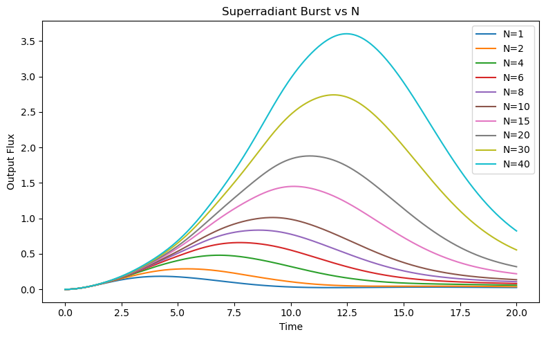

```python
plt.figure(figsize=(8,5))

for N in N_list:
    plt.plot(tlist, all_flux[N], label=f"N={N}")

plt.xlabel("Time")
plt.ylabel(r"Output Flux")
plt.title("Superradiant Burst vs N")
plt.legend()
plt.tight_layout()
plt.show()
```

*Figure 2: Output flux versus time for several values of N*.

To test if the scaling of peak power is indeed quadratic with N we plot peak fluxes versus $N^2$. If the scaling is quadratic we should see a linear graph. The code used for the plot of the relation is given below.

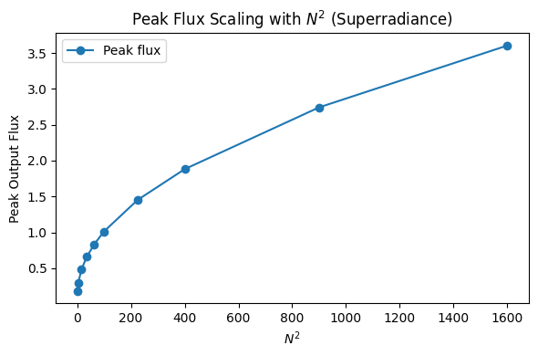

```python
# Compute peak fluxes
peak_fluxes = np.array([np.max(all_flux[N]) for N in N_list])

# Plot peak flux vs N^2
plt.figure(figsize=(6,4))
plt.plot(np.array(N_list)**2, peak_fluxes, 'o-', label='Peak flux')
plt.xlabel(r"$N^2$")
plt.ylabel("Peak Output Flux")
plt.title("Peak Flux Scaling with $N^2$ (Superradiance)")
plt.legend()
plt.tight_layout()
plt.show()
```

*Figure 3: Peak flux versus squared values of N.*

#### Cavity Wigner funciton during the superradiance burst

The Cavity Wigner funciton is used by us to visualize how the quantum state of the cavity field evolves in time during the superradiance burst for a N = 30 TLS. In the figure below this function is shown for three characteristic times: before the burst, at the peak of the emmited flux and at a later time.

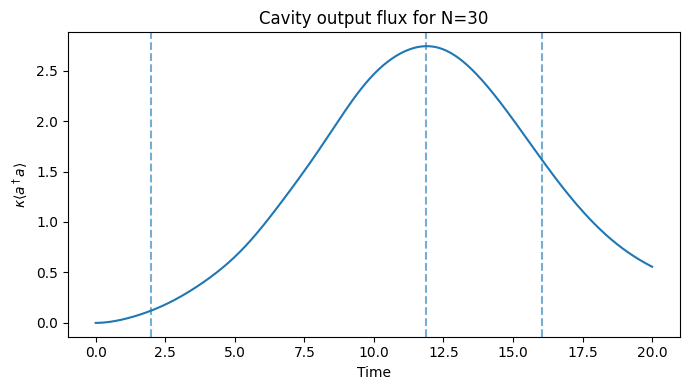

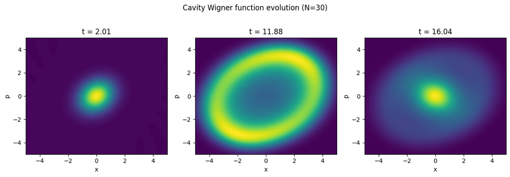

```python
plt.figure(figsize=(7,4))
plt.plot(tlist, flux, label="flux")
for idx, lab in zip(snapshot_indices, snapshot_labels):
    plt.axvline(tlist[idx], linestyle="--", alpha=0.6)
plt.xlabel("Time")
plt.ylabel(r"$\kappa \langle a^\dagger a \rangle$")
plt.title(f"Cavity output flux for N={N_wigner}")
plt.tight_layout()
plt.show()

from qutip import wigner

idx_early = int(0.10 * len(tlist))
idx_peak  = int(np.argmax(flux))
idx_late  = int(0.80 * len(tlist))
snapshot_indices = [idx_early, idx_peak, idx_late]
snapshot_labels  = [f"t = {tlist[i]:.2f}" for i in snapshot_indices]

xvec = np.linspace(-5, 5, 200)
pvec = np.linspace(-5, 5, 200)

fig, axes = plt.subplots(1, len(snapshot_indices), figsize=(4*len(snapshot_indices), 4))

for ax, idx, lab in zip(axes, snapshot_indices, snapshot_labels):
    rho_full = result.states[idx]
    rho_cav = rho_full.ptrace(0)

    W = wigner(rho_cav, xvec, pvec)

    im = ax.contourf(xvec, pvec, W, 100)
    ax.set_title(lab)
    ax.set_xlabel("x")
    ax.set_ylabel("p")

fig.suptitle(f"Cavity Wigner function evolution (N={N_wigner})", y=1.02)
plt.tight_layout()
plt.show()
```

*Figure 4: Cavity output flux (N=30) versus time and corresponding Wigner plots at specific times*.

## Effect of Decoherence on Superradiant Emission

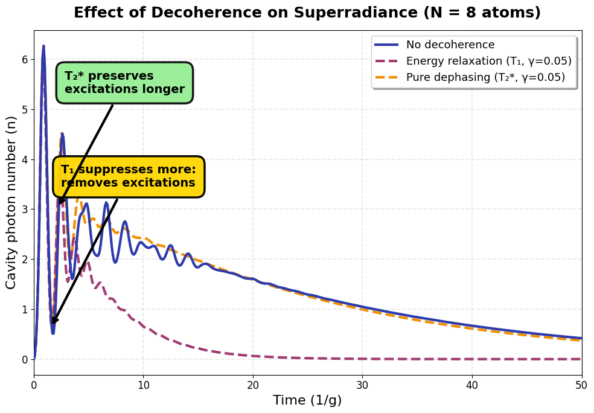

```python
fig, ax = plt.subplots(1, 1, figsize=(10, 7))
ax.plot(times, data_set['baseline'], label='No decoherence',
        color='#2E3BAB', linewidth=3, zorder=3)
ax.plot(times, data_set['method_a_0'], label='Energy relaxation (T₁, γ=0.05)',
        color='#A23B72', linewidth=3, linestyle='--', zorder=2)
ax.plot(times, data_set['method_b_0'], label='Pure dephasing (T₂*, γ=0.05)',
        color='#F18F01', linewidth=3, linestyle='--', zorder=1)
ax.set_xlabel('Time (1/g)', fontsize=16)
ax.set_ylabel('Cavity photon number (n)', fontsize=16)
ax.set_title(f'Effect of Decoherence on Superradiance (N = {N_atoms} atoms)',
             fontsize=18, fontweight='bold', pad=15)
ax.legend(frameon=True, shadow=True, loc='upper right', fontsize=13)
ax.grid(True, alpha=0.3, linestyle='--', linewidth=1.2)
ax.set_xlim([times[0], times[-1]])
peak_idx = np.argmax(data_set['baseline'])
ax.annotate('T₁ suppresses more:\nremoves excitations',
            xy=(times[int(peak_idx * 1.8)], data_set['method_a_0'][int(peak_idx * 1.8)]),
            xytext=(times[int(peak_idx * 2.8)], data_set['baseline'][peak_idx] * 0.55),
            arrowprops=dict(arrowstyle='->', color='black', lw=3),
            fontsize=14, fontweight='bold',
            bbox=dict(boxstyle='round,pad=0.7', facecolor='#FFD700', alpha=0.95,
                     edgecolor='black', linewidth=2.5))
ax.annotate('T₂* preserves\nexcitations longer',
            xy=(times[int(peak_idx * 2.5)], data_set['method_b_0'][int(peak_idx * 2.5)]),
            xytext=(times[int(peak_idx * 3.2)], data_set['baseline'][peak_idx] * 0.85),
            arrowprops=dict(arrowstyle='->', color='black', lw=3),
            fontsize=14, fontweight='bold',
            bbox=dict(boxstyle='round,pad=0.7', facecolor='#90EE90', alpha=0.9,
                     edgecolor='black', linewidth=2.5))
plt.tight_layout()
plt.savefig('figure_1.png', dpi=300, bbox_inches='tight')
plt.show()
```

*Figure 5: Cavity photon number over time. Energy relaxation $T_1$ (purple) supresses emission more than pure dephasing $T_2^*$ (orange) at the same decoherence rate ($\gamma = 0.05$).*

This difference arises because superradiance has a requirement of two conditions: one being available excitations (the resource) and the other being phase coherence (the coordination). $T_1$ processes destroy **both** simultaneously, energy loss inherently disrupts coherence. In contrast, $T_2^*$ affects only the coordination while trying to preserve the excitation reservoir.

## Entanglement Dynamics in Superradiance

Figure 6 reveals: all three coupling strengths saturate at the same maximum entropy ($S_{\max} \approx 3.16$ bits), but it reaches this particular limit at significantly different rates. Strong coupling attains saturation by $t \approx 0.3$ while weak coupling requires $t \approx 1.2$. Therefore, coupling strength controls the **rate** of entanglement generation compared to the final magnitude. The universal saturation at 3.16 bits reflects an important constraint: the 8-atom collective state spans a 9-dimensional Hilbert space ($N+1 = 9$), imposing a maximum entropy of $\log_2(9) \approx 3.17$ bits. Stronger coupling cannot exceed this limit as it is determined by the dimensionality of the Hilbert space.

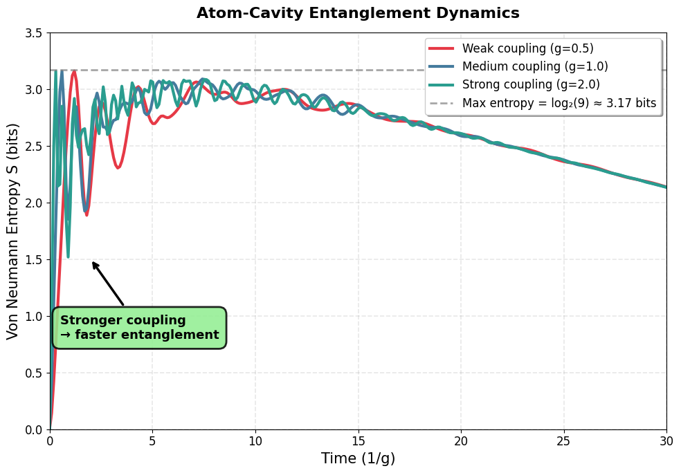

```python
fig, ax = plt.subplots(1, 1, figsize=(10, 7))
g_values = [0.5, 1.0, 2.0]

colors = ['#E63946', '#457B9D', '#2A9D8F']
labels = ['Weak coupling (g=0.5)', 'Medium coupling (g=1.0)', 'Strong coupling (g=2.0)']

for idx, g in enumerate(g_values):
    key = f'g_{g:.2f}'
    ax.plot(times_ent, entropy_results[key],
            color=colors[idx], linewidth=3, label=labels[idx])
max_entropy_theory = np.log2(int(N_atoms) + 1)
ax.axhline(y=max_entropy_theory, color='gray', linestyle='--',
           linewidth=2, alpha=0.7, label=f'Max entropy = log₂(9) ≈ {max_entropy_theory:.2f} bits')
ax.set_xlabel('Time (1/g)', fontsize=15)
ax.set_ylabel('Von Neumann Entropy S (bits)', fontsize=15)
ax.set_title('Atom-Cavity Entanglement Dynamics',
             fontsize=16, fontweight='bold', pad=15)
ax.legend(frameon=True, shadow=True, loc='upper right', fontsize=12)
ax.grid(True, alpha=0.3, linestyle='--', linewidth=1.2)
ax.set_xlim([0, 30])
ax.set_ylim([0, 3.5])
ax.annotate('Stronger coupling\n→ faster entanglement',
            xy=(2, 1.5),
            xytext=(0.5, 0.8),
            arrowprops=dict(arrowstyle='->', color='black', lw=2.5),
            fontsize=13, fontweight='bold',
            bbox=dict(boxstyle='round,pad=0.6', facecolor='lightgreen',
                     alpha=0.85, edgecolor='black', linewidth=2))

plt.tight_layout()
plt.savefig('figure_4.png', dpi=300, bbox_inches='tight')
plt.show()
```

Figure 7 quantifies this speedup: strong coupling reaches half-maximum entropy at $t_{1/2} = 0.20$ compared to $t_{1/2} = 0.60$ for weak coupling, precisely providing a threefold acceleration. This scaling occurs due to fact that the coupling constant sets the Rabi frequency, which governs the rate at which atoms and cavity exchange energy and build correlations. This analogy is instructive: stronger coupling functions as a larger channel, filling the system faster, but the capacity of container which is the Hilbert space dimension remains stagnant.

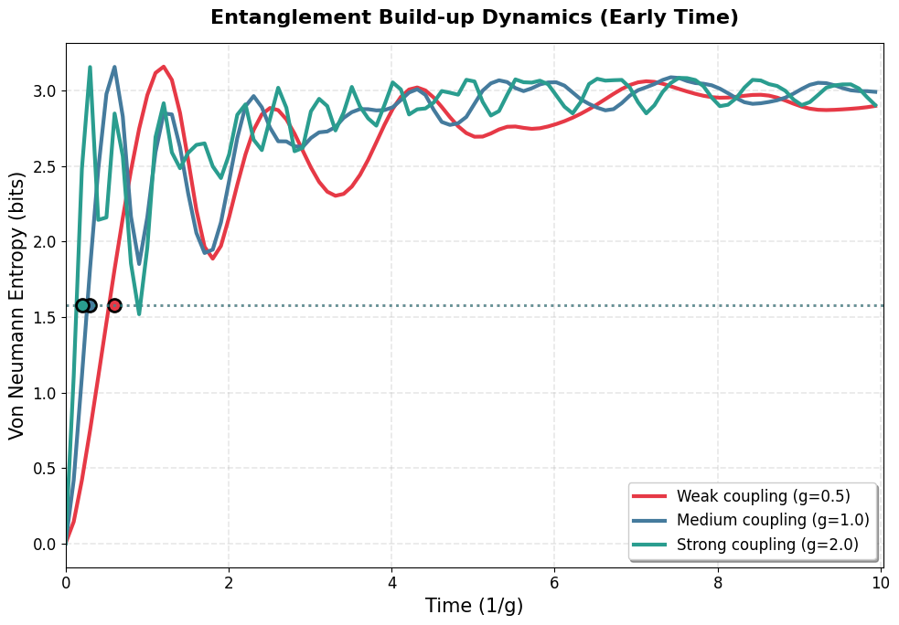

```python
fig, ax = plt.subplots(1, 1, figsize=(10, 7))

time_to_half_max = []
for idx, g in enumerate(g_values):
    key = f'g_{g:.2f}'
    max_ent = np.max(entropy_results[key])
    half_max = max_ent / 2
    time_idx = np.where(entropy_results[key] >= half_max)[0]
    if len(time_idx) > 0:
        t_half = times_ent[time_idx[0]]
        time_to_half_max.append(t_half)

        ax.plot(times_ent[:100], entropy_results[key][:100],
               color=colors[idx], linewidth=3, label=labels[idx])
        ax.axhline(y=half_max, color=colors[idx], linestyle=':', linewidth=2, alpha=0.5)
        ax.plot(t_half, half_max, 'o', color=colors[idx], markersize=10,
               markeredgecolor='black', markeredgewidth=2)
    else:
        time_to_half_max.append(np.nan)
ax.set_xlabel('Time (1/g)', fontsize=15)
ax.set_ylabel('Von Neumann Entropy (bits)', fontsize=15)
ax.set_title('Entanglement Build-up Dynamics (Early Time)', fontsize=16, fontweight='bold', pad=15)
ax.legend(frameon=True, shadow=True, loc='lower right', fontsize=12)
ax.grid(True, alpha=0.3, linestyle='--', linewidth=1.2)
ax.set_xlim([0, times_ent[100]])
plt.tight_layout()
plt.savefig('figure_6.png', dpi=300, bbox_inches='tight')
plt.show()
```

*Figure 7: Early-time entanglement buildup. Strong coupling reaches half-maximum three times faster than weak coupling.*

## Summary and outlook

We thought about some interesting extensions of our project. An interesting option would be to try and simulate 1/f noise, because this appears in superconducting qubits and quantum sensors. This way, we could study the behaviour of decoherence and entanglement under more complex noise dynamics. Moreover, we could try to extend the model to very large $N$ and see how the environment behaves. Furthermore, the phase-space perspective which is provided using Wigner functions could be used to study the usability in larger quantum systems. Our work in this project is relevant for applications in quantum sensing and quantum communication. Overall, the project could be extended toward more realistic simulation of open quantum systems.

## Author contributions

- Andrei Mosescu: $1/4$ of the report, Cavity Wigner Function, Decoherence effects, Entanglement between cavity and TLS collection
- Mario Nicolae: $1/4$ of the report, Cavity Wigner Function, Decoherence effects, Entanglement between cavity and TLS collection
- Matthias Fransen: $1/4$ of the report, Base Model and Simulation, Scaling of peak flux with $N^2$
- Axel Koning: $1/4$ of the report, Base Model and Simulation, Scaling of peak flux with $N^2$

## References

[1] Dicke, R. H. (1954). Coherence in Spontaneous Radiation Processes. Physical Review, 93(1), 99–110. https://doi.org/10.1103/physrev.93.99; https://journals.aps.org/pr/abstract/10.1103/PhysRev.93.99

[2] Pinhasi, Y., & Lurie, Y. (2002). Generalized theory and simulation of spontaneous and super-radiant emissions in electron devices and free-electron lasers. Physical Review. E, Statistical Physics, Plasmas, Fluids, And Related Interdisciplinary Topics, 65(2), 026501. https://doi.org/10.1103/physreve.65.026501; https://www.academia.edu/102527137/Generalized_theory_and_simulation_of_spontaneous_and_super_radiant_emissions_in_electron_devices_and_free_electron_lasers?uc-sb-sw=342826

[3] Hotter, C., Ostermann, L., & Ritsch, H. (2023). Cavity sub- and superradiance for transversely driven atomic ensembles. Physical Review Research, 5(1). https://doi.org/10.1103/physrevresearch.5.013056

[4] Ru, W. (2024). The electromagnetic vacuum field: a fundamental component of quantum-mechanical ontology. Journal Of Physical Mathematics. https://www.hilarispublisher.com/open-access/the-electromagnetic-vacuum-field-a-fundamental-component-of-quantummechanical-ontology-110645.html

[5] Johansson, J. R. (2014). Lecture 3A - The Dicke Model. https://nbviewer.org/urls/qutip.org/qutip-tutorials/tutorials-v5/lectures/Lecture-3A-Dicke-model.ipynb